# Example: Thrombolytic treatments

```r
library(multinma)
options(mc.cores = parallel::detectCores())
```

This vignette describes the analysis of 50 trials of 8 thrombolytic drugs (streptokinase, SK; alteplase, t-PA; accelerated alteplase, Acc t-PA; streptokinase plus alteplase, SK+tPA; reteplase, r-PA; tenocteplase, TNK; urokinase, UK; anistreptilase, ASPAC) plus per-cutaneous transluminal coronary angioplasty (PTCA) (Boland et al. 2003; Lu and Ades 2006; Dias et al. 2011, 2010). The number of deaths in 30 or 35 days following acute myocardial infarction are recorded. The data are available in this package as `thrombolytics`:

```r
head(thrombolytics)
```

```
#>   studyn trtn      trtc    r     n
#> 1      1    1        SK 1472 20251
#> 2      1    3  Acc t-PA  652 10396
#> 3      1    4 SK + t-PA  723 10374
#> 4      2    1        SK    9   130
#> 5      2    2      t-PA    6   123
#> 6      3    1        SK    5    63
```

## Setting up the network

We begin by setting up the network. We have arm-level count data giving the number of deaths (`r`) out of the total (`n`) in each arm, so we use the function `set_agd_arm()`. By default, SK is set as the network reference treatment.

```r
thrombo_net <- set_agd_arm(thrombolytics,
                           study = studyn,
                           trt = trtc,
                           r = r,
                           n = n)
thrombo_net
```

```
#> A network with 50 AgD studies (arm-based).
#>
#> ------------------------------------------------------- AgD studies (arm-based) ----
#>  Study Treatment arms
#>  1     3: SK | Acc t-PA | SK + t-PA
#>  2     2: SK | t-PA
#>  3     2: SK | t-PA
#>  4     2: SK | t-PA
#>  5     2: SK | t-PA
#>  6     3: SK | ASPAC | t-PA
#>  7     2: SK | t-PA
#>  8     2: SK | t-PA
#>  9     2: SK | t-PA
#>  10    2: SK | SK + t-PA
#>  ... plus 40 more studies
#>
#>  Outcome type: count
#> ------------------------------------------------------------------------------------
#> Total number of treatments: 9
#> Total number of studies: 50
#> Reference treatment is: SK
#> Network is connected
```

Plot the network structure.

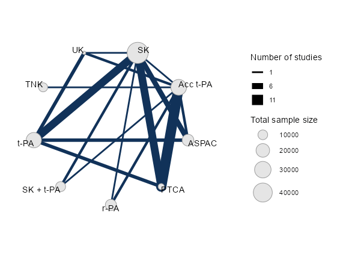

```r
plot(thrombo_net, weight_edges = TRUE, weight_nodes = TRUE)
```

## Fixed effects NMA

Following TSD 4 (Dias et al. 2011), we fit a fixed effects NMA model, using the `nma()` function with `trt_effects = "fixed"`. We use $\mathrm{N}(0, 100^2)$ prior distributions for the treatment effects $d_k$ and study-specific intercepts $\mu_j$. We can examine the range of parameter values implied by these prior distributions with the `summary()` method:

```r
summary(normal(scale = 100))
```

```
#> A Normal prior distribution: location = 0, scale = 100.
#> 50% of the prior density lies between -67.45 and 67.45.
#> 95% of the prior density lies between -196 and 196.
```

The model is fitted using the `nma()` function. By default, this will use a Binomial likelihood and a logit link function, auto-detected from the data.

```r
thrombo_fit <- nma(thrombo_net,
                   trt_effects = "fixed",
                   prior_intercept = normal(scale = 100),
                   prior_trt = normal(scale = 100))
```

```
#> Note: Setting "SK" as the network reference treatment.
```

Basic parameter summaries are given by the `print()` method:

```r
thrombo_fit
```

```
#> A fixed effects NMA with a binomial likelihood (logit link).
#> Inference for Stan model: binomial_1par.
#> 4 chains, each with iter=2000; warmup=1000; thin=1;
#> post-warmup draws per chain=1000, total post-warmup draws=4000.
#>
#>                   mean se_mean   sd      2.5%       25%       50%       75%     97.5% n_eff Rhat
#> d[Acc t-PA]      -0.18    0.00 0.04     -0.26     -0.21     -0.18     -0.15     -0.09  2720    1
#> d[ASPAC]          0.02    0.00 0.04     -0.06     -0.01      0.02      0.04      0.09  4711    1
#> d[PTCA]          -0.48    0.00 0.10     -0.68     -0.54     -0.48     -0.41     -0.28  4289    1
#> d[r-PA]          -0.12    0.00 0.06     -0.24     -0.16     -0.12     -0.08     -0.01  4066    1
#> d[SK + t-PA]     -0.05    0.00 0.05     -0.15     -0.08     -0.05     -0.02      0.04  6488    1
#> d[t-PA]           0.00    0.00 0.03     -0.06     -0.02      0.00      0.02      0.06  4416    1
#> d[TNK]           -0.17    0.00 0.08     -0.32     -0.22     -0.17     -0.12     -0.02  4065    1
#> d[UK]            -0.20    0.00 0.22     -0.62     -0.34     -0.20     -0.06      0.22  4544    1
#> lp__         -43042.88    0.15 5.37 -43053.99 -43046.49 -43042.62 -43039.15 -43033.15  1249    1
#>
#> Samples were drawn using NUTS(diag_e) at Mon Apr 29 16:34:10 2024.
#> For each parameter, n_eff is a crude measure of effective sample size,
#> and Rhat is the potential scale reduction factor on split chains (at
#> convergence, Rhat=1).
```

By default, summaries of the study-specific intercepts $\mu_j$ are hidden, but could be examined by changing the `pars` argument:

```r
# Not run
print(thrombo_fit, pars = c("d", "mu"))
```

The prior and posterior distributions can be compared visually using the `plot_prior_posterior()` function:

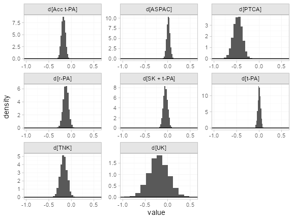

```r
plot_prior_posterior(thrombo_fit, prior = "trt")
```

Model fit can be checked using the `dic()` function

```r
(dic_consistency <- dic(thrombo_fit))
```

```
#> Residual deviance: 105.9 (on 102 data points)
#>                pD: 58.8
#>               DIC: 164.7
```

and the residual deviance contributions examined with the corresponding `plot()` method.

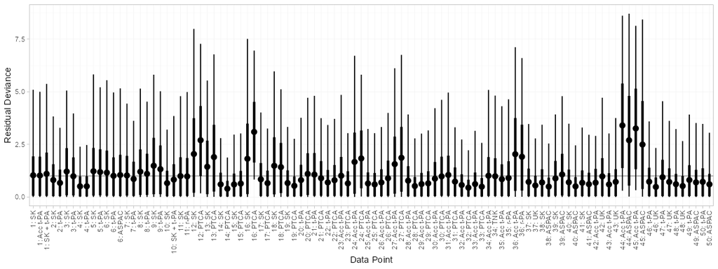

```r
plot(dic_consistency)
```

There are a number of points which are not very well fit by the model, having posterior mean residual deviance contributions greater than 1.

## Checking for inconsistency

> **Note:** The results of the inconsistency models here are slightly different to those of Dias et al. (2010, 2011), although the overall conclusions are the same. This is due to the presence of multi-arm trials and a different ordering of treatments, meaning that inconsistency is parameterised differently within the multi-arm trials. The same results as Dias et al. are obtained if the network is instead set up with `trtn` as the treatment variable.

### Unrelated mean effects model

We first fit an unrelated mean effects (UME) model (Dias et al. 2011) to assess the consistency assumption. Again, we use the function `nma()`, but now with the argument `consistency = "ume"`.

```r
thrombo_fit_ume <- nma(thrombo_net,
                       consistency = "ume",
                       trt_effects = "fixed",
                       prior_intercept = normal(scale = 100),
                       prior_trt = normal(scale = 100))
```

```
#> Note: Setting "SK" as the network reference treatment.
```

```r
thrombo_fit_ume
```

```
#> A fixed effects NMA with a binomial likelihood (logit link).
#> An inconsistency model ('ume') was fitted.
#> Inference for Stan model: binomial_1par.
#> 4 chains, each with iter=2000; warmup=1000; thin=1;
#> post-warmup draws per chain=1000, total post-warmup draws=4000.
#>
#>                            mean se_mean   sd      2.5%       25%       50%       75%     97.5%
#> d[Acc t-PA vs. SK]        -0.16    0.00 0.05     -0.25     -0.19     -0.16     -0.12     -0.06
#> d[ASPAC vs. SK]            0.01    0.00 0.04     -0.07     -0.02      0.01      0.03      0.08
#> d[PTCA vs. SK]            -0.67    0.00 0.18     -1.04     -0.79     -0.67     -0.54     -0.32
#> d[r-PA vs. SK]            -0.06    0.00 0.09     -0.24     -0.12     -0.06      0.00      0.12
#> d[SK + t-PA vs. SK]       -0.04    0.00 0.05     -0.14     -0.08     -0.04     -0.01      0.05
#> d[t-PA vs. SK]             0.00    0.00 0.03     -0.06     -0.02      0.00      0.02      0.06
#> d[UK vs. SK]              -0.37    0.01 0.52     -1.48     -0.70     -0.36      0.00      0.65
#> d[ASPAC vs. Acc t-PA]      1.41    0.01 0.43      0.62      1.12      1.39      1.68      2.31
#> d[PTCA vs. Acc t-PA]      -0.22    0.00 0.12     -0.45     -0.30     -0.22     -0.14      0.01
#> d[r-PA vs. Acc t-PA]       0.02    0.00 0.07     -0.11     -0.03      0.02      0.06      0.15
#> d[TNK vs. Acc t-PA]        0.00    0.00 0.07     -0.13     -0.04      0.00      0.05      0.14
#> d[UK vs. Acc t-PA]         0.14    0.01 0.35     -0.53     -0.10      0.14      0.36      0.87
#> d[t-PA vs. ASPAC]          0.29    0.01 0.36     -0.40      0.05      0.30      0.54      1.01
#> d[t-PA vs. PTCA]           0.54    0.01 0.42     -0.23      0.26      0.53      0.82      1.40
#> d[UK vs. t-PA]            -0.29    0.00 0.35     -1.00     -0.53     -0.28     -0.05      0.37
#> lp__                  -43039.92    0.16 5.79 -43052.07 -43043.73 -43039.61 -43035.85 -43029.50
#>                       n_eff Rhat
#> d[Acc t-PA vs. SK]     5654    1
#> d[ASPAC vs. SK]        4553    1
#> d[PTCA vs. SK]         5372    1
#> d[r-PA vs. SK]         6372    1
#> d[SK + t-PA vs. SK]    5868    1
#> d[t-PA vs. SK]         4361    1
#> d[UK vs. SK]           6082    1
#> d[ASPAC vs. Acc t-PA]  3106    1
#> d[PTCA vs. Acc t-PA]   5121    1
#> d[r-PA vs. Acc t-PA]   5327    1
#> d[TNK vs. Acc t-PA]    5692    1
#> d[UK vs. Acc t-PA]     3890    1
#> d[t-PA vs. ASPAC]      3702    1
#> d[t-PA vs. PTCA]       3865    1
#> d[UK vs. t-PA]         5333    1
#> lp__                   1381    1
#>
#> Samples were drawn using NUTS(diag_e) at Mon Apr 29 16:34:28 2024.
#> For each parameter, n_eff is a crude measure of effective sample size,
#> and Rhat is the potential scale reduction factor on split chains (at
#> convergence, Rhat=1).
```

Comparing the model fit statistics

```r
dic_consistency
```

```
#> Residual deviance: 105.9 (on 102 data points)
#>                pD: 58.8
#>               DIC: 164.7
```

```r
(dic_ume <- dic(thrombo_fit_ume))
```

```
#> Residual deviance: 100 (on 102 data points)
#>                pD: 66.3
#>               DIC: 166.3
```

Whilst the UME model fits the data better, having a lower residual deviance, the additional parameters in the UME model mean that the DIC is very similar between both models. However, it is also important to examine the individual contributions to model fit of each data point under the two models (a so-called “dev-dev” plot). Passing two `nma_dic` objects produced by the `dic()` function to the `plot()` method produces this dev-dev plot:

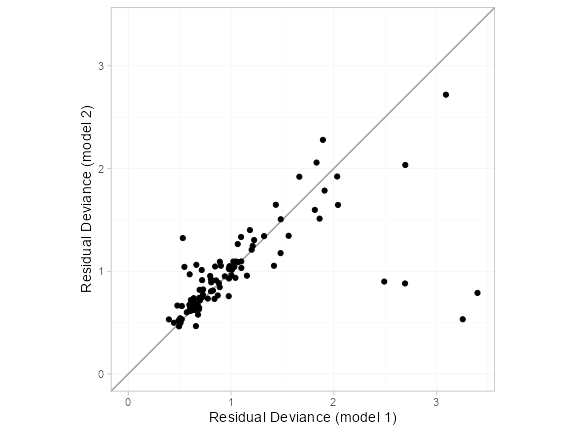

```r
plot(dic_consistency, dic_ume, show_uncertainty = FALSE)
```

The four points lying in the lower right corner of the plot have much lower posterior mean residual deviance under the UME model, indicating that these data are potentially inconsistent. These points correspond to trials 44 and 45, the only two trials comparing Acc t-PA to ASPAC. The ASPAC vs. Acc t-PA estimates are very different under the consistency model and inconsistency (UME) model, suggesting that these two trials may be systematically different from the others in the network.

### Node-splitting

Another method for assessing inconsistency is node-splitting (Dias et al. 2011, 2010). Whereas the UME model assesses inconsistency globally, node-splitting assesses inconsistency locally for each potentially inconsistent comparison (those with both direct and indirect evidence) in turn.

Node-splitting can be performed using the `nma()` function with the argument `consistency = "nodesplit"`. By default, all possible comparisons will be split (as determined by the `get_nodesplits()` function). Alternatively, a specific comparison or comparisons to split can be provided to the `nodesplit` argument.

```r
thrombo_nodesplit <- nma(thrombo_net,
                         consistency = "nodesplit",
                         trt_effects = "fixed",
                         prior_intercept = normal(scale = 100),
                         prior_trt = normal(scale = 100))
```

```
#> Fitting model 1 of 15, node-split: Acc t-PA vs. SK
#> Note: Setting "SK" as the network reference treatment.
#> Fitting model 2 of 15, node-split: ASPAC vs. SK
#> Note: Setting "SK" as the network reference treatment.
#> Fitting model 3 of 15, node-split: PTCA vs. SK
#> Note: Setting "SK" as the network reference treatment.
#> Fitting model 4 of 15, node-split: r-PA vs. SK
#> Note: Setting "SK" as the network reference treatment.
#> Fitting model 5 of 15, node-split: t-PA vs. SK
#> Note: Setting "SK" as the network reference treatment.
#> Fitting model 6 of 15, node-split: UK vs. SK
#> Note: Setting "SK" as the network reference treatment.
#> Fitting model 7 of 15, node-split: ASPAC vs. Acc t-PA
#> Note: Setting "SK" as the network reference treatment.
#> Fitting model 8 of 15, node-split: PTCA vs. Acc t-PA
#> Note: Setting "SK" as the network reference treatment.
#> Fitting model 9 of 15, node-split: r-PA vs. Acc t-PA
#> Note: Setting "SK" as the network reference treatment.
#> Fitting model 10 of 15, node-split: SK + t-PA vs. Acc t-PA
#> Note: Setting "SK" as the network reference treatment.
#> Fitting model 11 of 15, node-split: UK vs. Acc t-PA
#> Note: Setting "SK" as the network reference treatment.
#> Fitting model 12 of 15, node-split: t-PA vs. ASPAC
#> Note: Setting "SK" as the network reference treatment.
#> Fitting model 13 of 15, node-split: t-PA vs. PTCA
#> Note: Setting "SK" as the network reference treatment.
#> Fitting model 14 of 15, node-split: UK vs. t-PA
#> Note: Setting "SK" as the network reference treatment.
#> Fitting model 15 of 15, consistency model
#> Note: Setting "SK" as the network reference treatment.
```

The `summary()` method summarises the node-splitting results, displaying the direct and indirect estimates $d_\mathrm{dir}$ and $d_\mathrm{ind}$ from each node-split model, the network estimate $d_\mathrm{net}$ from the consistency model, the inconsistency factor $\omega = d_\mathrm{dir} - d_\mathrm{ind}$, and a Bayesian $p$-value for inconsistency on each comparison. The DIC model fit statistics are also provided. (If a random effects model was fitted, the heterogeneity standard deviation $\tau$ under each node-split model and under the consistency model would also be displayed.)

```r
summary(thrombo_nodesplit)
```

```
#> Node-splitting models fitted for 14 comparisons.
#>
#> ---------------------------------------------------- Node-split Acc t-PA vs. SK ----
#>
#>        mean   sd  2.5%   25%   50%   75% 97.5% Bulk_ESS Tail_ESS Rhat
#> d_net -0.18 0.04 -0.26 -0.21 -0.18 -0.15 -0.09     2771     3221    1
#> d_dir -0.16 0.05 -0.25 -0.19 -0.16 -0.13 -0.06     4529     3390    1
#> d_ind -0.25 0.09 -0.42 -0.31 -0.25 -0.18 -0.07      732     1407    1
#> omega  0.09 0.10 -0.11  0.02  0.09  0.16  0.29      855     1431    1
#>
#> Residual deviance: 106.4 (on 102 data points)
#>                pD: 59.9
#>               DIC: 166.3
#>
#> Bayesian p-value: 0.4
#>
#> ------------------------------------------------------- Node-split ASPAC vs. SK ----
#>
#>        mean   sd  2.5%   25%   50%   75% 97.5% Bulk_ESS Tail_ESS Rhat
#> d_net  0.01 0.04 -0.06 -0.01  0.02  0.04  0.08     4875     3646    1
#> d_dir  0.01 0.04 -0.06 -0.02  0.01  0.03  0.08     4493     3847    1
#> d_ind  0.43 0.24 -0.04  0.26  0.42  0.58  0.92     2438     2582    1
#> omega -0.42 0.25 -0.92 -0.57 -0.41 -0.25  0.06     2447     2761    1
#>
#> Residual deviance: 104 (on 102 data points)
#>                pD: 59.5
#>               DIC: 163.5
#>
#> Bayesian p-value: 0.084
#>
#> -------------------------------------------------------- Node-split PTCA vs. SK ----
#>
#>        mean   sd  2.5%   25%   50%   75% 97.5% Bulk_ESS Tail_ESS Rhat
#> d_net -0.48 0.10 -0.67 -0.54 -0.47 -0.41 -0.28     4233     3413    1
#> d_dir -0.66 0.18 -1.03 -0.78 -0.66 -0.54 -0.30     5574     3448    1
#> d_ind -0.39 0.12 -0.63 -0.47 -0.39 -0.31 -0.16     3695     3328    1
#> omega -0.27 0.22 -0.71 -0.42 -0.28 -0.12  0.17     4819     3447    1
#>
#> Residual deviance: 105.5 (on 102 data points)
#>                pD: 59.8
```

[output cut: 142 more lines]

```
#> Bayesian p-value: 0.89
#>
#> -------------------------------------------------------- Node-split UK vs. t-PA ----
#>
#>        mean   sd  2.5%   25%   50%   75% 97.5% Bulk_ESS Tail_ESS Rhat
#> d_net -0.20 0.22 -0.64 -0.35 -0.20 -0.05  0.24     4050     3437    1
#> d_dir -0.29 0.34 -0.99 -0.51 -0.29 -0.06  0.39     5502     3322    1
#> d_ind -0.15 0.29 -0.72 -0.34 -0.15  0.05  0.40     3833     3204    1
#> omega -0.14 0.45 -1.03 -0.44 -0.14  0.16  0.75     4132     3187    1
#>
#> Residual deviance: 106.7 (on 102 data points)
#>                pD: 59.6
#>               DIC: 166.2
#>
#> Bayesian p-value: 0.76
```

Node-splitting the ASPAC vs. Acc t-PA comparison results the lowest DIC, and this is lower than the consistency model. The posterior distribution for the inconsistency factor $\omega$ for this comparison lies far from 0 and the Bayesian $p$-value for inconsistency is small (< 0.01), meaning that there is substantial disagreement between the direct and indirect evidence on this comparison.

We can visually compare the direct, indirect, and network estimates using the `plot()` method.

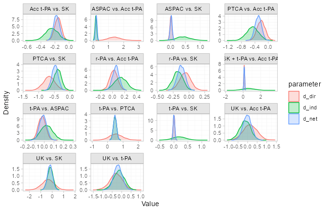

```r
plot(thrombo_nodesplit)
```

We can also plot the posterior distributions of the inconsistency factors $\omega$, again using the `plot()` method. Here, we specify a “halfeye” plot of the posterior density with median and credible intervals, and customise the plot layout with standard `ggplot2` functions.

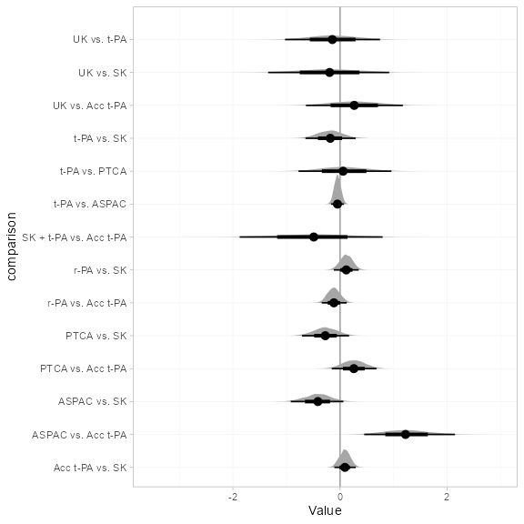

```r
plot(thrombo_nodesplit, pars = "omega", stat = "halfeye", ref_line = 0) +
  ggplot2::aes(y = comparison) +
  ggplot2::facet_null()
```

Notice again that the posterior distribution of the inconsistency factor for the ASPAC vs. Acc t-PA comparison lies far from 0, indicating substantial inconsistency between the direct and indirect evidence on this comparison.

## Further results

Relative effects for all pairwise contrasts between treatments can be produced using the `relative_effects()` function, with `all_contrasts = TRUE`.

```r
(thrombo_releff <- relative_effects(thrombo_fit, all_contrasts = TRUE))
```

```
#>                            mean   sd  2.5%   25%   50%   75% 97.5% Bulk_ESS Tail_ESS Rhat
#> d[Acc t-PA vs. SK]        -0.18 0.04 -0.26 -0.21 -0.18 -0.15 -0.09     2741     3350    1
#> d[ASPAC vs. SK]            0.02 0.04 -0.06 -0.01  0.02  0.04  0.09     4759     3407    1
#> d[PTCA vs. SK]            -0.48 0.10 -0.68 -0.54 -0.48 -0.41 -0.28     4224     3597    1
#> d[r-PA vs. SK]            -0.12 0.06 -0.24 -0.16 -0.12 -0.08 -0.01     4124     3378    1
#> d[SK + t-PA vs. SK]       -0.05 0.05 -0.15 -0.08 -0.05 -0.02  0.04     6639     3326    1
#> d[t-PA vs. SK]             0.00 0.03 -0.06 -0.02  0.00  0.02  0.06     4463     3091    1
#> d[TNK vs. SK]             -0.17 0.08 -0.32 -0.22 -0.17 -0.12 -0.02     4091     3038    1
#> d[UK vs. SK]              -0.20 0.22 -0.62 -0.34 -0.20 -0.06  0.22     4556     3292    1
#> d[ASPAC vs. Acc t-PA]      0.19 0.06  0.08  0.16  0.19  0.23  0.30     3357     3353    1
#> d[PTCA vs. Acc t-PA]      -0.30 0.10 -0.49 -0.37 -0.30 -0.23 -0.11     5487     3643    1
#> d[r-PA vs. Acc t-PA]       0.05 0.06 -0.05  0.02  0.05  0.09  0.16     6249     2933    1
#> d[SK + t-PA vs. Acc t-PA]  0.13 0.06  0.02  0.09  0.13  0.17  0.24     6088     3327    1
#> d[t-PA vs. Acc t-PA]       0.18 0.05  0.07  0.14  0.18  0.21  0.28     3080     3121    1
#> d[TNK vs. Acc t-PA]        0.01 0.06 -0.12 -0.04  0.01  0.05  0.13     5654     3453    1
#> d[UK vs. Acc t-PA]        -0.02 0.22 -0.45 -0.17 -0.03  0.12  0.40     4578     3063    1
#> d[PTCA vs. ASPAC]         -0.49 0.11 -0.71 -0.56 -0.49 -0.42 -0.28     4343     3622    1
#> d[r-PA vs. ASPAC]         -0.14 0.07 -0.28 -0.19 -0.14 -0.09  0.00     4270     3496    1
#> d[SK + t-PA vs. ASPAC]    -0.07 0.06 -0.18 -0.11 -0.06 -0.02  0.05     6404     3289    1
#> d[t-PA vs. ASPAC]         -0.01 0.04 -0.09 -0.04 -0.01  0.01  0.06     7805     3544    1
#> d[TNK vs. ASPAC]          -0.19 0.08 -0.35 -0.24 -0.19 -0.13 -0.02     4124     2951    1
#> d[UK vs. ASPAC]           -0.22 0.22 -0.65 -0.36 -0.22 -0.07  0.21     4728     3259    1
#> d[r-PA vs. PTCA]           0.35 0.11  0.14  0.28  0.35  0.43  0.57     5766     3472    1
#> d[SK + t-PA vs. PTCA]      0.43 0.11  0.22  0.35  0.43  0.50  0.63     5397     3817    1
#> d[t-PA vs. PTCA]           0.48 0.10  0.28  0.41  0.48  0.55  0.68     4154     3498    1
#> d[TNK vs. PTCA]            0.31 0.12  0.08  0.23  0.30  0.38  0.53     6257     3758    1
#> d[UK vs. PTCA]             0.27 0.23 -0.19  0.11  0.27  0.43  0.73     4615     3242    1
#> d[SK + t-PA vs. r-PA]      0.07 0.07 -0.06  0.02  0.07  0.12  0.22     6839     2932    1
#> d[t-PA vs. r-PA]           0.13 0.07  0.00  0.08  0.12  0.17  0.26     4057     3331    1
#> d[TNK vs. r-PA]           -0.05 0.08 -0.21 -0.10 -0.05  0.01  0.11     7604     2842    1
#> d[UK vs. r-PA]            -0.08 0.22 -0.51 -0.23 -0.08  0.07  0.35     4716     3247    1
#> d[t-PA vs. SK + t-PA]      0.05 0.06 -0.06  0.01  0.05  0.09  0.16     5685     3464    1
#> d[TNK vs. SK + t-PA]      -0.12 0.09 -0.29 -0.18 -0.12 -0.07  0.04     6530     3150    1
#> d[UK vs. SK + t-PA]       -0.15 0.22 -0.58 -0.29 -0.15 -0.01  0.28     4727     3191    1
#> d[TNK vs. t-PA]           -0.17 0.08 -0.33 -0.23 -0.17 -0.12 -0.01     4012     3099    1
#> d[UK vs. t-PA]            -0.20 0.22 -0.63 -0.34 -0.21 -0.06  0.21     4714     3193    1
#> d[UK vs. TNK]             -0.03 0.23 -0.47 -0.19 -0.03  0.13  0.41     4500     3426    1
```

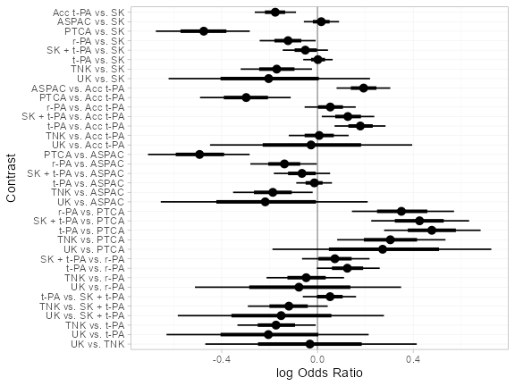

```r
plot(thrombo_releff, ref_line = 0)
```

Treatment rankings, rank probabilities, and cumulative rank probabilities.

```r
(thrombo_ranks <- posterior_ranks(thrombo_fit))
```

```
#>                 mean   sd 2.5% 25% 50% 75% 97.5% Bulk_ESS Tail_ESS Rhat
#> rank[SK]        7.45 0.96    6   7   7   8     9     3439       NA    1
#> rank[Acc t-PA]  3.18 0.82    2   3   3   4     5     4266     3613    1
#> rank[ASPAC]     7.96 1.15    5   7   8   9     9     4561       NA    1
#> rank[PTCA]      1.12 0.33    1   1   1   1     2     4043     3044    1
#> rank[r-PA]      4.42 1.15    2   4   5   5     7     5081     3571    1
#> rank[SK + t-PA] 6.00 1.28    4   5   6   6     9     5022       NA    1
#> rank[t-PA]      7.48 1.09    5   7   8   8     9     5092       NA    1
#> rank[TNK]       3.50 1.27    2   3   3   4     6     4599     3260    1
#> rank[UK]        3.89 2.67    1   2   2   5     9     4579       NA    1
```

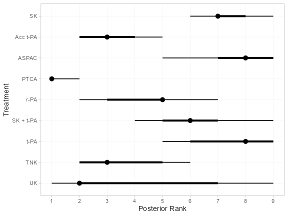

```r
plot(thrombo_ranks)
```

```r
(thrombo_rankprobs <- posterior_rank_probs(thrombo_fit))
```

```
#>              p_rank[1] p_rank[2] p_rank[3] p_rank[4] p_rank[5] p_rank[6] p_rank[7] p_rank[8]
#> d[SK]             0.00      0.00      0.00      0.00      0.02      0.13      0.39      0.31
#> d[Acc t-PA]       0.00      0.20      0.46      0.28      0.05      0.00      0.00      0.00
#> d[ASPAC]          0.00      0.00      0.00      0.00      0.03      0.10      0.18      0.26
#> d[PTCA]           0.88      0.12      0.00      0.00      0.00      0.00      0.00      0.00
#> d[r-PA]           0.00      0.05      0.14      0.31      0.38      0.09      0.01      0.01
#> d[SK + t-PA]      0.00      0.00      0.01      0.06      0.25      0.44      0.09      0.07
#> d[t-PA]           0.00      0.00      0.00      0.00      0.04      0.15      0.30      0.32
#> d[TNK]            0.00      0.24      0.31      0.25      0.15      0.04      0.01      0.01
#> d[UK]             0.12      0.38      0.07      0.09      0.10      0.05      0.02      0.02
#>              p_rank[9]
#> d[SK]             0.15
#> d[Acc t-PA]       0.00
#> d[ASPAC]          0.43
#> d[PTCA]           0.00
#> d[r-PA]           0.01
#> d[SK + t-PA]      0.06
#> d[t-PA]           0.20
#> d[TNK]            0.00
#> d[UK]             0.14
```

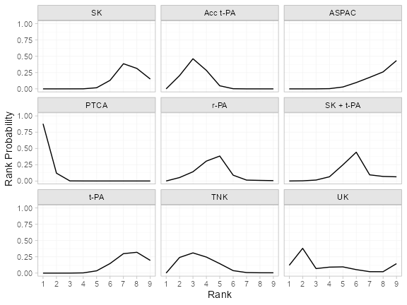

```r
plot(thrombo_rankprobs)
```

```r
(thrombo_cumrankprobs <- posterior_rank_probs(thrombo_fit, cumulative = TRUE))
```

```
#>              p_rank[1] p_rank[2] p_rank[3] p_rank[4] p_rank[5] p_rank[6] p_rank[7] p_rank[8]
#> d[SK]             0.00      0.00      0.00      0.00      0.02      0.15      0.54      0.85
#> d[Acc t-PA]       0.00      0.20      0.67      0.95      1.00      1.00      1.00      1.00
#> d[ASPAC]          0.00      0.00      0.00      0.00      0.03      0.13      0.31      0.57
#> d[PTCA]           0.88      1.00      1.00      1.00      1.00      1.00      1.00      1.00
#> d[r-PA]           0.00      0.05      0.19      0.50      0.88      0.97      0.99      0.99
#> d[SK + t-PA]      0.00      0.00      0.02      0.08      0.33      0.77      0.87      0.94
#> d[t-PA]           0.00      0.00      0.00      0.00      0.04      0.19      0.48      0.80
#> d[TNK]            0.00      0.24      0.55      0.80      0.94      0.98      0.99      1.00
#> d[UK]             0.12      0.50      0.57      0.66      0.76      0.81      0.83      0.86
#>              p_rank[9]
#> d[SK]                1
#> d[Acc t-PA]          1
#> d[ASPAC]             1
#> d[PTCA]              1
#> d[r-PA]              1
#> d[SK + t-PA]         1
#> d[t-PA]              1
#> d[TNK]               1
#> d[UK]                1
```

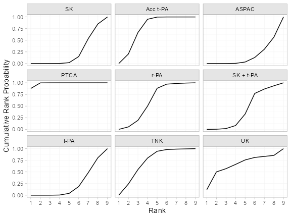

```r
plot(thrombo_cumrankprobs)
```

## References

Boland, A., Y. Dundar, A. Bagust, A. Haycox, R. Hill, R. Mujica Mota, T. Walley, and R. Dickson. 2003. “Early Thrombolysis for the Treatment of Acute Myocardial Infarction: A Systematic Review and Economic Evaluation.” *Health Technology Assessment* 7 (15). https://doi.org/10.3310/hta7150.

Dias, S., N. J. Welton, D. M. Caldwell, and A. E. Ades. 2010. “Checking Consistency in Mixed Treatment Comparison Meta-Analysis.” *Statistics in Medicine* 29 (7-8): 932–44. https://doi.org/10.1002/sim.3767.

Dias, S., N. J. Welton, A. J. Sutton, D. M. Caldwell, G. Lu, and A. E. Ades. 2011. “NICE DSU Technical Support Document 4: Inconsistency in Networks of Evidence Based on Randomised Controlled Trials.” National Institute for Health and Care Excellence. https://www.sheffield.ac.uk/nice-dsu.

Lu, G. B., and A. E. Ades. 2006. “Assessing Evidence Inconsistency in Mixed Treatment Comparisons.” *Journal of the American Statistical Association* 101 (474): 447–59. https://doi.org/10.1198/016214505000001302.